# Validate SBL Experiment Procedure using Chow and Liu (1999)

# Cross-over analysis

Before we can do T-Tests or an ANOVA we need check for carryover effects.

## Test for Period and Carryover effects

Note that we were not able replicate the exact numbers. However we also failed to reject the assumption of equal period effects at the 0.05 significance level and failed to reject the assumption of equal carryover effects at the 0.05 significance level.

```r
p2 <- df %>%
  group_by(subject, sequence) %>%
  summarize(total = response[1]+response[2])
p2
```

### Period Effect

Results are nearly the same.

```r
## two-sided, paired t-test --> period effect
t.test(response ~ period , data = df, paired = TRUE, conf.level = 0.95, alternative = "two.sided")
```

### Carryover Effect

Results are not the same as in NCSS doc.

```r
## two-sided, paired t-test --> carryover effect
t.test(response ~ sequence, data = df, paired = TRUE, conf.level = 0.95, alternative = "two.sided")
```

using totals

```r
## two-sided, paired t-test --> carryover effect
t.test(total ~ sequence, data = p2, paired = TRUE, conf.level = 0.95, alternative = "two.sided")
```

Validation: we could not exactly replicate the numbers, however also failed to reject assumption for null hypotheses of period and carryover effects.

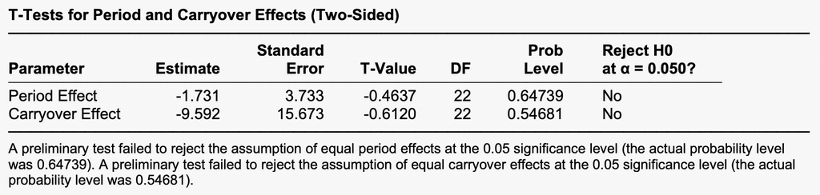

Figure 3: Period and Carryover Effects from NCSS Documentation (Screenshot from [NCSS documentation](https://www.ncss.com/wp-content/themes/ncss/pdf/Procedures/NCSS/Analysis_of_2x2_Cross-Over_Designs_using_T-Tests.pdf))

# T-Test for Treatment Effect

We cannot exactly replicate the values with separate T-Tests but get very close, however with a linear mixed model as shown below we can exactly replicate the results from the NCSS documentation. In both cases (t-tests and linear mixed model) the two treatment means in a 2x2 cross-over study are not significantly different as also documented in the NCSS documentation.

```r
## two-sided, paired t-test
t.test(x = df$response[df$treatment == "nl"], y = df$response[df$treatment == "kv"], paired = TRUE, conf.level = 0.95, alternative = "two.sided")
```

# Analysis of Variance (linear mixed model) using lmer

Based on input from Thomas Rusch (WU Vienna [Competence Center for Empirical Research Methods](https://www.wu.ac.at/en/methods/)) using a linear mixed model and a slideset (Lukas Meier: [Multiple Treatments on the Same Experimental Unit](https://ethz.ch/content/dam/ethz/special-interest/math/statistics/sfs/Education/Advanced%20Studies%20in%20Applied%20Statistics/course-material/repeatedMeasures/4_crossover.pdf)) which references [Jones and Kenward (2014)](https://doi.org/10.1201/b17537) explaining how to model a carryover effect as a sequence effect or as an interaction effect.

Linear mixed model including carryover effect as a sequence effect

```r
###### Part 1: Linear Regression (Linear Mixed Model) ####
# based on input from Thomas Rusch + slideset from Meier
# model as a sequence effect
m_seq<-lmer(response~treatment+period+sequence+(1|subject),data=df)
# Madeyski and Kitchenham actually argue to leave out sequence
#m_seq<-lmer(response~period+treatment+(1|subject),data=df)
#anova(m_seq)
summary(m_seq)
#fixef(m_seq)

## extract coefficients
#coefs_seq <- data.frame(coef(summary(m_seq)))
#coefs_seq$df.Satt <- coef(summary(m_seq))[, 3]
## get approximate p-values
#coefs_seq$p.Satt <- coef(summary(m_seq))[, 5]
#coefs_seq
```

```r
coefs_final <- coefs_seq
coefs_final %>% filter(rownames(coefs_final) %in% c('treatmentnl'))
coefs_final
```

```r
anova(m_seq)
F_to_eta2(0.3754, df = 1, df_error = 22)
```

Linear mixed model including carryover effect as an interaction effect

```r
###### Part 2: Linear Regression (Linear Mixed Model) ####
# based on input from Thomas Rusch + slideset from Meier
# model as an interaction effect
m_int<-lmer(response~treatment*period+(1|subject),data=df)
#anova(m_int)
summary(m_int)
fixef(m_int)

# extract coefficients
coefs_int <- data.frame(coef(summary(m_int)))
coefs_int$df.Satt <- coef(summary(m_int))[, 3]
# get approximate p-values
coefs_int$p.Satt <- coef(summary(m_int))[, 5]
coefs_int
```

```r
anova(m_int, m_seq)
```

Multiple Comparisons of Means: Tukey Contrasts

```r
summary(glht(m_seq, linfct=mcp(treatment="Tukey")))

confint(m_seq)
```

We replicated period and carryover effects and also the treatment effect. All from the linear mixed models. The above would still need some code refinements and cleanups (TODO).

**Where to read the correct values:**

- Period effect is used from model based on sequence effect (m_seq)
- Carryover effect is used from model based on interaction effect (m_int)
- Treatment effect can be used from both models (same result)

# Analysis of Variance (one-way ANOVA) using aov

Based on input from Stefan Sobernig

```r
# lmer formula: response~treatment+period+sequence+(1|subject)
# source: https://stats.stackexchange.com/questions/71914/what-does-the-anova-command-do-with-a-lmer-model-object?newreg=9a9a41dc9b154ae09f9aec1620081ba6
model <- aov(response~treatment+period+sequence+Error(subject/treatment), data=df)
summary(model)
```

Tukey HSD

```r
TukeyHSD(model, "treatment", conf.level=.95, ordered = TRUE)
```

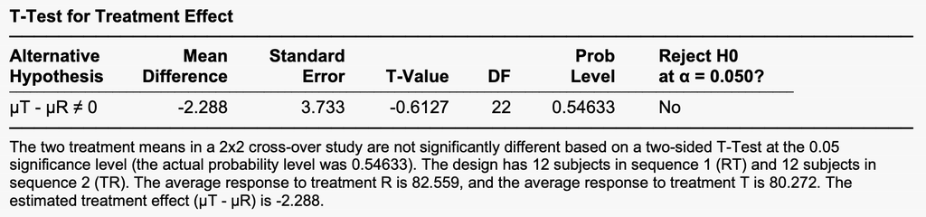

Figure 4: T-Test for Treatment Effect from NCSS Documentation(Screenshot from [NCSS documentation](https://www.ncss.com/wp-content/themes/ncss/pdf/Procedures/NCSS/Analysis_of_2x2_Cross-Over_Designs_using_T-Tests.pdf))

# Plot of Sequence-by-Period Means

Note that this plot can be replicated.

```r
np <- df %>%
  group_by(treatment, period) %>%
  summarize(mean = mean(response))

pd = position_dodge(0)
np.plot <- ggplot(np, aes(x = period,
               y = mean,
               color = treatment,
               group = treatment)) +
  geom_point(shape  = 15,
             size   = 4,
             position = pd) +
  geom_line() + theme(
    legend.position = c(.99, .99),
    legend.justification = c("right", "top"),
    legend.box.just = "right",
    legend.margin = margin(4, 4, 4, 4),
    axis.title   = element_text(face = "bold"),
    axis.text    = element_text(face = "bold"),
    plot.caption = element_text(hjust = 0)
  ) +
  scale_x_continuous(limits = c(0.5, 2.5),breaks=seq(1,2),minor_breaks=NULL) +
  ylab("Mean Response") +
  xlab("Period") +
  labs(color = "Treatment")

np.plot
```

See the following plot from the NCSS documentation for validation reference

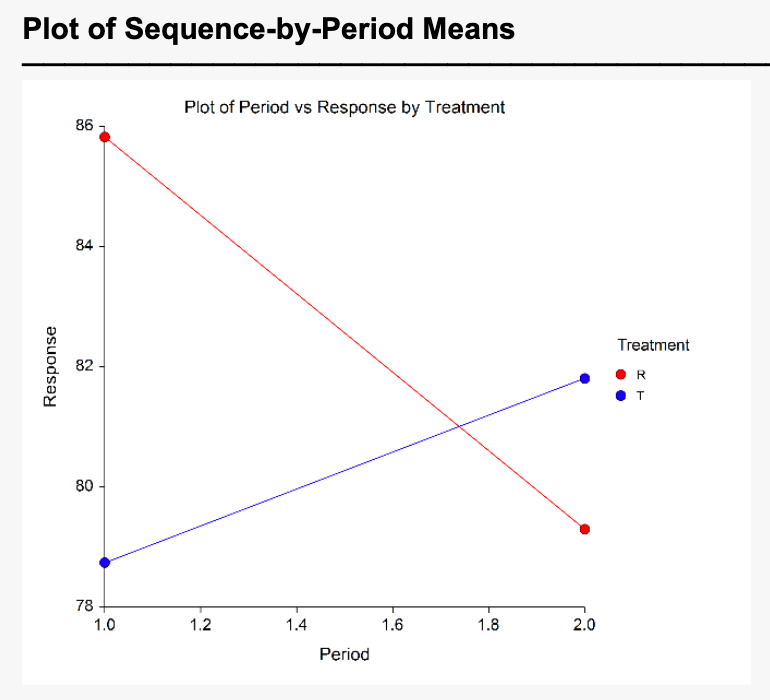

**Additional notes and tests from 11.08.2023**

Effect Size

```r
# R-squared
performance::r2(m_seq)

# F2 calculations
# Source: https://joshuawiley.com/MonashHonoursStatistics/LMM_Comparison.html

# Calculate conditional F2
F2c <- (0.636^2)/(1-0.636^2)
F2c

# Calculate marginal F2
F2m <- (0.017^2)/(1-0.017^2)
F2m

# Backup
# Partial eta-square
anova(m_seq)
F_to_eta2(0.3754, df = 1, df_error = 22)

# Beta coefficient
effectsize(m_int)
#effectsize::standardize_parameters(model_seq, method = "pseudo")
#effectsize::standardize_parameters(model_seq, method = "refit")
```

Tukey HSD

```r
N <- 48 # sample size
k <- 2 # number of treatments
n <- N / k # number of samples per group

# Mean Square
plants <- split(df, df$treatment)

sse <- sum(Reduce('+', lapply(plants, function(x) {
  (length(x[,1]) - 1) * sd(x[,1])^2
})))

mse <- sse / (N - k)
mse
confint(m_seq)

# q-value
q.value <- qtukey(p = 0.95, nmeans = k, df = N - k)
q.value

tukey.hsd <- q.value * sqrt(mse/n)
tukey.hsd

means <- tapply(df$response, df$sequence, mean)
trt1.ctrl.diff <- means[2] - means[1]
trt1.ctrl.diff

trt1.ctrl.diff.upper <- trt1.ctrl.diff + q.value * sqrt(mse / 2 * (2 / n))
trt1.ctrl.diff.lower <- trt1.ctrl.diff - q.value * sqrt(mse / 2 * (2 / n))
trt1.ctrl.diff.lower
trt1.ctrl.diff.upper
```